# 04_plot

Angel Huang

11/10/2020

# 1 Prepare data

## Load libraries

```r
# Install EDA related libraries
library(tidyverse)
```

```r
library(ggplot2)
library(gridExtra)
#library(plyr)
library(dplyr) # for group by
#library(tidyr)
```

## Load data from rdata that was generated by 01_make_data in data folder

```r
load("../../data/students_df.RData")
#df <- read.csv(file = "../../data/TEST_FILE_WEEK2_V2.csv")
dim(students_df)
```

```
## [1] 14238    37
```

```r
str(students_df) # list of each variable
```

```
## 'data.frame':    14238 obs. of  37 variables:
##  $ UNIQUE_ID             : Factor w/ 14238 levels "SID_100013","SID_100046",..: 1 2 3 4 5 6 7 8 9 10 ...
##  $ STRM                  : int  2192 2192 2192 2192 2192 2192 2192 2192 2192 2192 ...
##  $ STRM_DESC             : Factor w/ 1 level "Spring 2019": 1 1 1 1 1 1 1 1 1 1 ...
##  $ IS_RETAINED           : int  1 1 1 1 1 1 1 0 1 1 ...
##  $ IS_RETAINED_DESC      : Factor w/ 2 levels "Did Not Return Next Term",..: 2 2 2 2 2 2 2 1 2 2 ...
##  $ RESIDENCY_CODE        : Factor w/ 2 levels "I","O": 2 1 2 1 1 2 1 1 1 1 ...
##  $ RESIDENCY             : Factor w/ 2 levels "In-State","Out-of-State": 2 1 2 1 1 2 1 1 1 1 ...
##  $ ACAD_CAREER_STUDENT   : Factor w/ 1 level "UGRD": 1 1 1 1 1 1 1 1 1 1 ...
##  $ CLASS_LEVEL_STUDENT   : Factor w/ 4 levels "FR","JR","SO",..: 3 4 2 3 2 3 3 3 3 3 ...
##  $ IS_DEGREE_SEEKING     : int  1 1 1 1 1 1 1 1 1 1 ...
##  $ INTENDED_DECLARED     : Factor w/ 2 levels "D","I": 2 1 2 2 1 2 2 2 2 2 ...
##  $ INTENDED_DECLARED_DESC: Factor w/ 2 levels "Declared Major",..: 2 1 2 2 1 2 2 2 2 2 ...
##  $ IS_DBL_MAJOR          : int  1 0 1 0 0 0 0 1 0 0 ...
##  $ MAJ_1_SCHOOL_CODE     : Factor w/ 10 levels "CAS","KFBS","SILS",..: 1 1 1 1 1 1 1 1 1 1 ...
```

[output cut: 23 more lines]

```r
summary(students_df)
```

```
##       UNIQUE_ID          STRM            STRM_DESC      IS_RETAINED
##  SID_100013:    1   Min.   :2192   Spring 2019:14238   Min.   :0.0000
##  SID_100046:    1   1st Qu.:2192                       1st Qu.:1.0000
##  SID_100259:    1   Median :2192                       Median :1.0000
##  SID_100348:    1   Mean   :2192                       Mean   :0.9674
##  SID_100429:    1   3rd Qu.:2192                       3rd Qu.:1.0000
##  SID_100541:    1   Max.   :2192                       Max.   :1.0000
##  (Other)   :14232
##                  IS_RETAINED_DESC RESIDENCY_CODE        RESIDENCY
##  Did Not Return Next Term:  464   I:11769        In-State    :11769
##  Returned Next Term      :13774   O: 2469        Out-of-State: 2469
##
##
##
##
##
##  ACAD_CAREER_STUDENT CLASS_LEVEL_STUDENT IS_DEGREE_SEEKING INTENDED_DECLARED
##  UGRD:14238          FR:1857             Min.   :1         D:7820
##                      JR:5275             1st Qu.:1         I:6418
##                      SO:4265             Median :1
##                      SR:2841             Mean   :1
##                                          3rd Qu.:1
##                                          Max.   :1
##
##     INTENDED_DECLARED_DESC  IS_DBL_MAJOR    MAJ_1_SCHOOL_CODE
##  Declared Major:7820       Min.   :0.0000   CAS    :10726
##  Intended Major:6418       1st Qu.:0.0000   KFBS   : 1270
##                            Median :0.0000   SOJ    : 1019
##                            Mean   :0.2238   SON    :  424
##                            3rd Qu.:0.0000   SPH    :  312
##                            Max.   :1.0000   SOE    :  220
##                                             (Other):  267
##             MAJ_1_SCHOOL_NAME MAJ_1_DIV_CODE
##  Arts and Sciences   :10726   NS     :6589
##  Business            : 1270   SB     :2322
##  Media and Journalism: 1019   BU     :1270
##  Nursing             :  424   MJ     :1019
##  Global Public Health:  312   AS     : 848
##  Education           :  220   HU     : 751
##  (Other)             :  267   (Other):1439
```

[output cut: 49 more lines]

```
##  2018 Fall  :5153   Min.   :  0.000    Min.   : 0.00     Min.   : 1.00
##  2017 Fall  :4564   1st Qu.:  0.000    1st Qu.: 0.00     1st Qu.:13.00
##  2016 Fall  :3765   Median :  0.000    Median :10.00     Median :15.00
##  2019 Spring: 286   Mean   :  8.416    Mean   :11.63     Mean   :14.26
##  2015 Fall  : 179   3rd Qu.:  4.000    3rd Qu.:19.00     3rd Qu.:16.00
##  2018 Spring:  95   Max.   :127.000    Max.   :70.00     Max.   :22.00
##  (Other)    : 196
##  CREDIT_HOURS_EARNED
##  Min.   : 0.00
##  1st Qu.:12.00
##  Median :14.00
##  Mean   :13.25
##  3rd Qu.:15.00
##  Max.   :22.00
##
```

```r
df = students_df
```

## Transformation of variables

```r
# convert variables to factor
df$RESIDENCY_CODE = factor(df$RESIDENCY_CODE)
df$CLASS_LEVEL_STUDENT = factor(df$CLASS_LEVEL_STUDENT)
df$MAJ_1_SCHOOL_NAME = factor(df$MAJ_1_SCHOOL_NAME)
df$STU_ORIG_ENROLL_STATUS = factor(df$STU_ORIG_ENROLL_STATUS)
df$FAC_IS_RETAINED = factor(df$IS_RETAINED)

# reorder levels of class
df$ORDER_CLASS_LEVEL_STUDENT = ordered(df$CLASS_LEVEL_STUDENT, levels = c('FR','SO','JU','SR'))
# check level
levels(df$ORDER_CLASS_LEVEL_STUDENT)
```

```
## [1] "FR" "SO" "JU" "SR"
```

```r
# check contrast
contrasts(df$ORDER_CLASS_LEVEL_STUDENT)
```

```
##              .L   .Q         .C
## [1,] -0.6708204  0.5 -0.2236068
## [2,] -0.2236068 -0.5  0.6708204
## [3,]  0.2236068 -0.5 -0.6708204
## [4,]  0.6708204  0.5  0.2236068
```

```r
# log transform variables
df$LOG_TRNSFR_UNITS_ENTRY = log(df$TRNSFR_UNITS_ENTRY+0.1) # add a small number to make sure log is not inf
df$LOG_TEST_CREDIT_ENTRY = log(df$TEST_CREDIT_ENTRY+0.1)
# engineer new feature
df$CREDIT_HOURS_FAILED = df$CREDIT_HOURS_ATT - df$CREDIT_HOURS_EARNED
df$CREDIT_HOURS_FAILPER = df$CREDIT_HOURS_FAILED / df$CREDIT_HOURS_ATT
```

I reordered the class level so that it makes more sense – from low to high grade. Since some variables are skewed, I created log transform of those variables for linear models later.

### Classification and Regression Tree (CART)

```r
library(rpart)
```

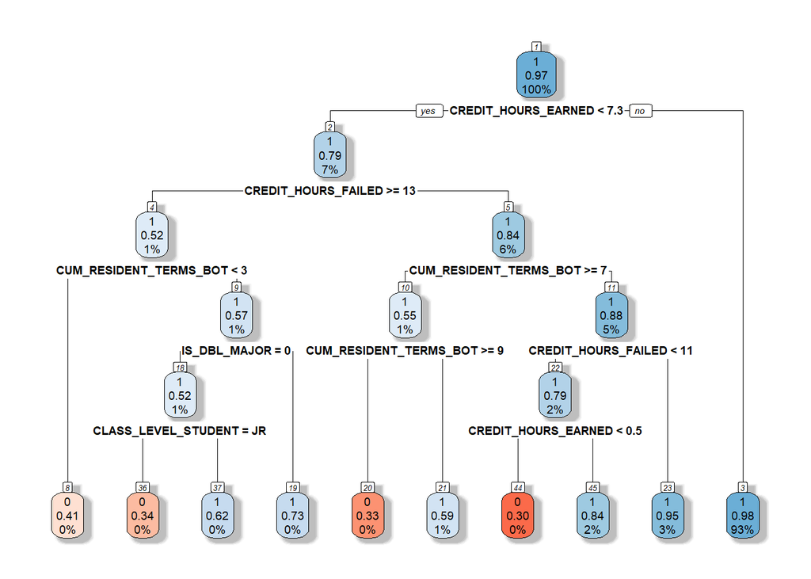

```r
library(rpart.plot)
#Build the model
# For classification tree, response needs to be factor
# tree doesn't need log transform
ml_formula3 = formula(FAC_IS_RETAINED ~ RESIDENCY_CODE + CLASS_LEVEL_STUDENT + IS_DBL_MAJOR + MAJ_1_SCHOOL_NAME + CUM_RESIDENT_TERMS_BOT + TRNSFR_UNITS_ENTRY + TEST_CREDIT_ENTRY + CREDIT_HOURS_FAILED + CREDIT_HOURS_EARNED)

ml_tree = rpart(ml_formula3,data=df,cp=0.008) # cp for complexity, smaller cp =more branches

#Summarize the model
#summary(ml_tree)
# Visualize the decision tree with rpart.plot
rpart.plot(ml_tree, box.palette="RdBu", shadow.col="gray", nn=TRUE)
```

First, we do a density plot to visually verify the split

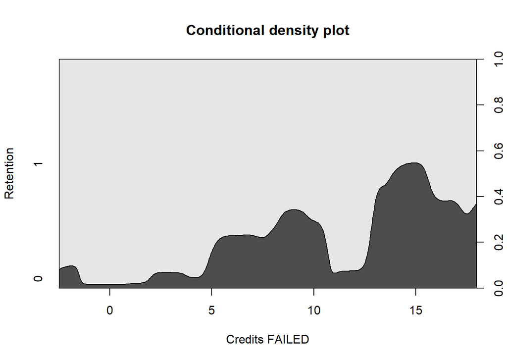

```r
cdplot(factor(IS_RETAINED) ~ CREDIT_HOURS_FAILED,
       df,
       #col=c("lightgoldenrod", "lightcyan"),
       ylab = "Retention", xlab ="Credits FAILED", main = "Conditional density plot")
```

More failed credits, more dropout. The split happens at <=5, <13, consistent with the tree split.

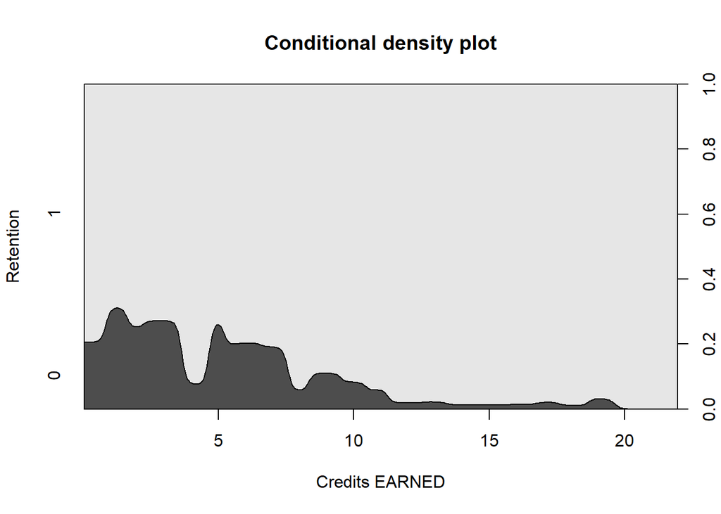

```r
cdplot(factor(IS_RETAINED) ~ CREDIT_HOURS_EARNED,
       df,
       #col=c("lightgoldenrod", "lightcyan"),
       ylab = "Retention", xlab ="Credits EARNED", main = "Conditional density plot")
```

The split happens at <4, <7.3, consistent with the tree split.

## Create new variables

```r
# convert variables to factor
df$FAILED = cut(
  df$CREDIT_HOURS_FAILED,
  breaks = c(-Inf, 5, 13, Inf), # If use 0 for the first one will make all entries with 0 into NA
  labels = c("low_<=5", "med_5<=13", "high_13<=Inf"),
  right  = TRUE # include right hand number
)
df$EARNED = cut(
  df$CREDIT_HOURS_EARNED,
  breaks = c(-Inf, 4, 7, Inf),
  labels = c("low_<=4", "med_4<=7", "high_7<=Inf"),
  right  = TRUE # include right hand number
)
```

# 3. GLM model

```r
glm1 <- glm(IS_RETAINED ~ FAILED*EARNED,
            data = df,
            family = binomial(link = "logit"))
summary(glm1)
```

```
##
## Call:
## glm(formula = IS_RETAINED ~ FAILED * EARNED, family = binomial(link = "logit"),
##     data = df)
##
## Deviance Residuals:
##     Min       1Q   Median       3Q      Max
## -2.8523   0.1858   0.1858   0.1858   1.1387
##
## Coefficients: (2 not defined because of singularities)
##                                      Estimate Std. Error z value Pr(>|z|)
## (Intercept)                            0.5167     0.2167   2.384 0.017105 *
## FAILEDmed_5<=13                        1.3055     0.2476   5.273 1.34e-07 ***
## FAILEDhigh_13<=Inf                    -0.4249     0.2894  -1.468 0.142010
## EARNEDmed_4<=7                         1.2854     0.3461   3.714 0.000204 ***
## EARNEDhigh_7<=Inf                      3.5339     0.2269  15.573  < 2e-16 ***
## FAILEDmed_5<=13:EARNEDmed_4<=7        -2.0090     0.4177  -4.809 1.52e-06 ***
## FAILEDhigh_13<=Inf:EARNEDmed_4<=7          NA         NA      NA       NA
## FAILEDmed_5<=13:EARNEDhigh_7<=Inf     -3.9389     0.3429 -11.486  < 2e-16 ***
## FAILEDhigh_13<=Inf:EARNEDhigh_7<=Inf       NA         NA      NA       NA
## ---
## Signif. codes:  0 '***' 0.001 '**' 0.01 '*' 0.05 '.' 0.1 ' ' 1
##
## (Dispersion parameter for binomial family taken to be 1)
##
##     Null deviance: 4090.0  on 14237  degrees of freedom
## Residual deviance: 3369.4  on 14231  degrees of freedom
## AIC: 3383.4
##
## Number of Fisher Scoring iterations: 6
```

```r
#glm2 <- glm(IS_RETAINED ~ FAILED*CLASS_LEVEL_STUDENT*IS_DBL_MAJOR,
#            data = df,
#            family = binomial(link = "logit"))
#summary(glm2)
glm3 <- glm(IS_RETAINED ~ FAILED*CLASS_LEVEL_STUDENT,
            data = df,
            family = binomial(link = "logit"))
summary(glm3)
```

```
##
## Call:
## glm(formula = IS_RETAINED ~ FAILED * CLASS_LEVEL_STUDENT, family = binomial(link = "logit"),
##     data = df)
##
## Deviance Residuals:
##     Min       1Q   Median       3Q      Max
## -2.8727   0.1804   0.2019   0.2186   1.3018
##
## Coefficients:
##                                          Estimate Std. Error z value Pr(>|z|)
## (Intercept)                                3.7222     0.1562  23.837  < 2e-16
## FAILEDmed_5<=13                           -3.0291     0.3215  -9.423  < 2e-16
## FAILEDhigh_13<=Inf                        -4.0099     0.4678  -8.572  < 2e-16
## CLASS_LEVEL_STUDENTJR                      0.3878     0.1930   2.009  0.04449
## CLASS_LEVEL_STUDENTSO                      0.1612     0.1915   0.842  0.40002
## CLASS_LEVEL_STUDENTSR                     -0.1739     0.1977  -0.879  0.37915
## FAILEDmed_5<=13:CLASS_LEVEL_STUDENTJR      0.9323     0.3793   2.458  0.01396
## FAILEDhigh_13<=Inf:CLASS_LEVEL_STUDENTJR  -0.1607     0.5941  -0.271  0.78674
## FAILEDmed_5<=13:CLASS_LEVEL_STUDENTSO      0.2908     0.4034   0.721  0.47094
## FAILEDhigh_13<=Inf:CLASS_LEVEL_STUDENTSO   0.4319     0.5960   0.725  0.46865
## FAILEDmed_5<=13:CLASS_LEVEL_STUDENTSR      1.1522     0.3765   3.060  0.00221
## FAILEDhigh_13<=Inf:CLASS_LEVEL_STUDENTSR   0.8293     0.6493   1.277  0.20153
##
## (Intercept)                              ***
## FAILEDmed_5<=13                          ***
## FAILEDhigh_13<=Inf                       ***
## CLASS_LEVEL_STUDENTJR                    *
## CLASS_LEVEL_STUDENTSO
## CLASS_LEVEL_STUDENTSR
## FAILEDmed_5<=13:CLASS_LEVEL_STUDENTJR    *
## FAILEDhigh_13<=Inf:CLASS_LEVEL_STUDENTJR
## FAILEDmed_5<=13:CLASS_LEVEL_STUDENTSO
## FAILEDhigh_13<=Inf:CLASS_LEVEL_STUDENTSO
## FAILEDmed_5<=13:CLASS_LEVEL_STUDENTSR    **
## FAILEDhigh_13<=Inf:CLASS_LEVEL_STUDENTSR
## ---
## Signif. codes:  0 '***' 0.001 '**' 0.01 '*' 0.05 '.' 0.1 ' ' 1
##
## (Dispersion parameter for binomial family taken to be 1)
##
##     Null deviance: 4090.0  on 14237  degrees of freedom
## Residual deviance: 3535.7  on 14226  degrees of freedom
## AIC: 3559.7
##
## Number of Fisher Scoring iterations: 6
```

```r
ml_formula1 = formula(IS_RETAINED ~ RESIDENCY_CODE + IS_DBL_MAJOR + MAJ_1_SCHOOL_NAME + CUM_RESIDENT_TERMS_BOT + LOG_TRNSFR_UNITS_ENTRY + LOG_TEST_CREDIT_ENTRY + FAILED*CLASS_LEVEL_STUDENT + CREDIT_HOURS_ATT)

glm4 = glm(ml_formula1,data=df,family = binomial(link = "logit"))
#summary(glm4)
sub_df = df[,c("RESIDENCY_CODE", "IS_DBL_MAJOR", "MAJ_1_SCHOOL_NAME","CUM_RESIDENT_TERMS_BOT", "LOG_TRNSFR_UNITS_ENTRY","LOG_TEST_CREDIT_ENTRY","FAILED","CLASS_LEVEL_STUDENT", "CREDIT_HOURS_ATT")]
df$pred = predict(glm4,sub_df,type="response")
```